[figure not shown]

# Gaussian Blur

It is a widely used effect in graphics software, typically to **reduce image noise and reduce detail.**

The visual effect of this blurring technique is a smooth blur resembling that of viewing the image through a translucent screen.

#### Edge detection

Gaussian smoothing is commonly used with edge detection. Most edge-detection algorithms are sensitive to noise; the 2-D Laplacian filter, built from a discretization of the Laplace operator, is highly sensitive to noisy environments.

Using a Gaussian Blur filter before edge detection aims to reduce the level of noise in the image, which improves the result of the following edge-detection algorithm. This approach is commonly referred to as Laplacian of Gaussian, or LoG filtering.

#### Photography

Lower-end digital cameras, including many mobile phone cameras, commonly use gaussian blurring to cover up image noise caused by higher ISO light sensitivities.

#### Let's get coding

1. Firstly we import and image
2. Then we generate a gaussian kernel
3. After that we apply the kernel to the image by cross-correlation (misnomer - convolution)

```python
import numpy as np
import pandas as pd
from plotnine import *
```

```python
from matplotlib.pyplot import imread,imshow
```

```python
im = imread("./images/dtu.png")
im = np.mean(im/255. , axis=2)
im = im[:256 , :256]
```

[figure not shown]

```python
imshow(im , cmap='gray')
```

## Plotting the Image as a 3D Scatter

- To plot the image as a 3D scatter we will leverage matplotlib's mplot3d
- mplot3d offers a lot of functionality of 3d plotting
- the functions we will use here are scatter and plot_surface

#### Why ?

This provides us with another way to visualize the impact of the filter (gaussian blur) that we are going to apply

`ax.scatter(x,y,z)`

This function takes as input the x and y coordinate arrays and the z (height in this case) values as the z parameter To get the x,y and z values we use

`np.ndenumerate` which outputs for each pixel in the image, its coordinate x,y and the value

```python
data = np.array([(*index , val) for index,val in np.ndenumerate(im)])
x = data[: ,0]
y  = data[: ,1]
z = data[: ,2]
```

```python
%matplotlib inline
```

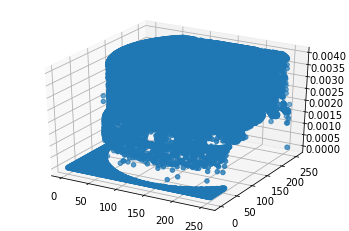

```python
import matplotlib.pyplot as plt
from mpl_toolkits.mplot3d import Axes3D
from matplotlib import cm
fig = plt.figure()
ax = fig.add_subplot(111, projection='3d')
ax.scatter(x,y,z , cmap=cm.coolwarm)
```

We can somewhat oberserve the shape and see that the white regions of the image are evlevated and the black ones are floored.

## Making our own kernel

Let's get to the filter part.

Imagine the kernel as a matrix of size `n x n`

To make our own gaussian filter the approach is going to be

- Use `np.random.multivariate_normal` to sample points with specific mean and covaraince matrices
- The mean would depend on the size of the kernel that we want and would be at the center of the kernel.
- Once we have our points in the 2D space we will do an accumulation to see how many points lie in each of the box of the matrix and summing that would give us the value for each of the box

For example in the 8x8 grid below we have filled the random normal points. As one would expect the points have higher density in the center and become sparser away from the center i.e 4,4

Now when we count the points , box (0,1) has one point , (0,5) has 2 and so on.

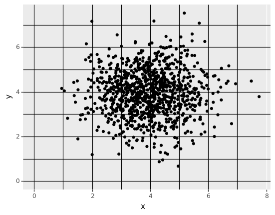

```python
(
    ggplot(pd.DataFrame(np.random.multivariate_normal([4,4] , [[1,0], [0,1]] , 1000) , columns=["x","y"]))
    + geom_point(aes(x="x" , y="y"))
    + geom_hline(yintercept=np.arange(0,8))
    + geom_vline(xintercept=np.arange(0,8))
)
```

```python
from ipywidgets import widgets , interact , fixed
```

### Implementation

The below code chunk captures in code the idea that was mentioned.

Major burden is being handled by

- `np.random.multivariate_normal` generates the points
- `updateKernel` function that counts the number of points in each box

```python
#def applyFilter(meana , meanb):
kernel_n = 12
cells = [i for i in range(kernel_n)]
middle = kernel_n//2
gaussian_kernel = np.random.multivariate_normal([middle,middle] , [[1,0], [0,1]] , 10000)
kernel = np.zeros((kernel_n , kernel_n))
```

```python
def updateKernel(kernel,i):
    i,j = list(i)
    kernel[i,j] += 1
    return kernel
```

```python
for i in np.round(gaussian_kernel).astype(int):
        kernel = updateKernel(kernel,i)
```

### Looking at the generated kernel

```python
kernel
```

```
array([[0.000e+00, 0.000e+00, 0.000e+00, 0.000e+00, 0.000e+00, 0.000e+00,
        0.000e+00, 0.000e+00, 0.000e+00, 0.000e+00, 0.000e+00, 0.000e+00],
       [0.000e+00, 0.000e+00, 0.000e+00, 0.000e+00, 0.000e+00, 0.000e+00,
        0.000e+00, 0.000e+00, 0.000e+00, 0.000e+00, 0.000e+00, 0.000e+00],
       [0.000e+00, 0.000e+00, 0.000e+00, 0.000e+00, 1.000e+00, 0.000e+00,
        3.000e+00, 0.000e+00, 0.000e+00, 0.000e+00, 0.000e+00, 0.000e+00],
       [0.000e+00, 0.000e+00, 0.000e+00, 0.000e+00, 4.000e+00, 1.900e+01,
        2.200e+01, 1.700e+01, 3.000e+00, 0.000e+00, 0.000e+00, 0.000e+00],
       [0.000e+00, 0.000e+00, 0.000e+00, 2.000e+00, 4.300e+01, 1.440e+02,
        2.350e+02, 1.460e+02, 3.900e+01, 1.000e+00, 0.000e+00, 0.000e+00],
       [0.000e+00, 0.000e+00, 0.000e+00, 1.300e+01, 1.300e+02, 5.650e+02,
        9.240e+02, 5.660e+02, 1.330e+02, 1.100e+01, 2.000e+00, 0.000e+00],
       [0.000e+00, 0.000e+00, 0.000e+00, 2.500e+01, 2.330e+02, 9.250e+02,
        1.521e+03, 9.470e+02, 2.200e+02, 1.900e+01, 1.000e+00, 0.000e+00],
       [0.000e+00, 0.000e+00, 0.000e+00, 1.700e+01, 1.490e+02, 5.600e+02,
        9.280e+02, 5.880e+02, 1.490e+02, 2.100e+01, 0.000e+00, 0.000e+00],
       [0.000e+00, 0.000e+00, 0.000e+00, 5.000e+00, 3.400e+01, 1.470e+02,
        2.140e+02, 1.500e+02, 3.700e+01, 9.000e+00, 1.000e+00, 0.000e+00],
       [0.000e+00, 0.000e+00, 0.000e+00, 0.000e+00, 4.000e+00, 1.500e+01,
        2.400e+01, 2.400e+01, 6.000e+00, 0.000e+00, 1.000e+00, 0.000e+00],
       [0.000e+00, 0.000e+00, 0.000e+00, 0.000e+00, 0.000e+00, 0.000e+00,
        2.000e+00, 1.000e+00, 0.000e+00, 0.000e+00, 0.000e+00, 0.000e+00],
       [0.000e+00, 0.000e+00, 0.000e+00, 0.000e+00, 0.000e+00, 0.000e+00,
        0.000e+00, 0.000e+00, 0.000e+00, 0.000e+00, 0.000e+00, 0.000e+00]])
```

Okay so that was not helpful. Lets visualize it.

### Kernel in 3D

To do kernel in 3D we will rely on `matplotlib's plot_surface`

```python
X = np.arange(0, kernel_n, 1)
Y = np.arange(0, kernel_n, 1)
```

```python
X,Y = np.meshgrid(X, Y)
```

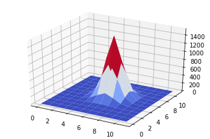

```python
fig = plt.figure()
ax = fig.add_subplot(111, projection='3d')
ax.plot_surface(X,Y,kernel, cmap=cm.coolwarm)
plt.show();
```

Not *normal* enough but will do!

### Applying the Kernel to the Image

Now we have our filter and the image. Let's put the two together.

We could use `scipy's convolve2d` but that would be too easy. And more importantly we won't know *how* it works.

SO how it works is..

Take the kernel/filter and move it across the image.

[figure not shown]

[source](https://towardsdatascience.com/intuitively-understanding-convolutions-for-deep-learning-1f6f42faee1)

Here the blue grid is the image, green is the output and the grey thing moving is the kernel.

In the code below, a trick is employed. Instead of looping over and computing the cross convolution. We loop over only to collect the patches and then broadcast to compute the cross convolution.

```python
def apply_filter(im , kernel):
    ih = im.shape[0]
    iw = im.shape[1]
    kh = kernel.shape[0]
    kw = kernel.shape[1]

    outimg = np.zeros((ih-kh+1 , iw-kw+1))
    patches = []

    for index, val in np.ndenumerate(outimg):
        i,j = index
        patch = im[i:i+kh , j:j+kw]
        patches.append(patch)

    patches = np.dstack(patches)
    return np.sum(np.multiply(patches , kernel.reshape(kh,kw,1)) , axis=(0,1)).reshape(outimg.shape[0],outimg.shape[1])
```

[figure not shown]

```python
imshow(apply_filter(im , kernel) , cmap='gray')
```

### Making things interactive

okay now we got our filter applied to the image. But how about if we change the kernel size ? What happens then ?

Let's make things interactive using `ipywidgets`! Play around with the slider and look for yourself.

```python
def kernel_play(im,showFunc , size=9):
    #def applyFilter(meana , meanb):
    kernel_n = size
    cells = [i for i in range(kernel_n)]
    middle = kernel_n//2
    gaussian_kernel = np.random.multivariate_normal([middle,middle] , [[middle/4,0], [0,middle/4]] , 10000)
    kernel = np.zeros((kernel_n , kernel_n))
    for i in np.floor(gaussian_kernel).astype(int):
        kernel = updateKernel(kernel,i)
    #_= [updateKernel(i) for i in np.round(gaussian_kernel).astype(int)]
    im = apply_filter(im, kernel)
    showFunc(im)
```

```python
interact(kernel_play
         , im=fixed(im)
         ,showFunc=fixed(lambda im : imshow(im , cmap='gray'))
         ,size=widgets.IntSlider(min=5 , step=2))
```

```
<function __main__.kernel_play(im, showFunc, size=9)>
```

```python
def imToSurface(im):
    X = np.arange(0, im.shape[1], 1)
    Y = np.arange(0, im.shape[0], 1)
    X,Y = np.meshgrid(X, Y)
    fig = plt.figure(figsize=(15,6))
    ax = fig.add_subplot(1,2,1, projection='3d')
    ax.plot_surface(X,Y,im, cmap=cm.coolwarm)

    ax2 = fig.add_subplot(1,2,2)
    ax2.imshow(im , cmap='gray')
    plt.show();
```

```python
interact(kernel_play
         , im=fixed(im)
         ,showFunc=fixed(lambda im : imToSurface(im))
         ,size=widgets.IntSlider(min=9 , step=2))
```

```
<function __main__.kernel_play(im, showFunc, size=9)>
```